# STAT 5533 Project Report: Predicting Student Grades

Anish Paudyal

2025-04-26

## Introduction

### Motivation

Understanding the factors that influence student performance is crucial for educators and policymakers to improve educational outcomes. This project aims to predict students’ final grades (G3) using various predictors and assess the effectiveness of different regression techniques.

### Questions to be Answered

We explore the following research questions:

*1. Can we predict a student’s final grade (G3) based on the existing predictors?*

*2. Does feature selection improve predictive accuracy?*

*3. How does dimensionality reduction affect predictive performance?*

### Description of the Data

The dataset comprises 1044 observations from two Portuguese secondary schools, with 30 predictors and three response variables (G1, G2, G3). Grades range from 0 to 20. We focus on: - **data1**: Full dataset with all observations and predictors. - **data4**: Dataset with G3=0 observations removed and predictors G1 and G2 excluded.

## Methodology

### Data Processing

We combined `student-mat.csv` and `student-por.csv` into a dataset of 1044 observations. Two datasets were created: - **data1**: All observations and predictors. - **data4**: Observations with G3=0 removed, G1 and G2 removed.

An 80/20 train-test split was applied to each dataset.

### Analysis Techniques

We applied seven regression techniques:

1. Multiple Linear Regression (MLR)
2. Lasso Regression
3. Ridge Regression
4. Principal Component Regression (PCR)
5. Support Vector Regression (SVR) with linear, polynomial, and radial kernels
6. Bayesian Additive Regression Trees (BART)
7. Tree-based Regression

These methods compare linear vs. non-linear models, feature selection (Lasso), and dimensionality reduction (PCR).

### Similarities and Differences Between Methods

- **MLR**: Baseline linear model.
- **Lasso and Ridge**: Regularized linear models; Lasso performs feature selection.
- **PCR**: Reduces dimensionality using principal components.
- **SVR**: Captures non-linear relationships via kernels.
- **BART and Tree-based Regression**: Non-parametric methods capturing complex interactions.

## Results

### Predictive Performance

```r
# Create MSE table for data1 and data4
mse_data <- data.frame(
  Model = c("MLR", "Lasso", "Ridge", "PCR", "SVR Linear", "SVR Polynomial", "SVR Radial", "BART", "Tree-based"),
  MSE_data1 = c(mse_mlr_1, mse_lasso_1, mse_ridge_1, mse_pcr_1, mse_svr_linear_1, mse_svr_poly_1, mse_svr_radial_1, mse_bart_1, mse_tree_1),
  MSE_data4 = c(mse_mlr_4, mse_lasso_4, mse_ridge_4, mse_pcr_4, mse_svr_linear_4, mse_svr_poly_4, mse_svr_radial_4, mse_bart_4, mse_tree_4)
)

# Format table for HTML output
knitr::kable(mse_data, format = "html", caption = "Mean Squared Error (MSE) for regression models on data1 and data4. Bold indicates the best-performing model for each dataset.", digits = 2) %>%
  kableExtra::kable_styling(bootstrap_options = c("striped", "hover")) %>%
  kableExtra::row_spec(which.min(mse_data$MSE_data1), bold = TRUE, extra_css = "font-weight: bold;") %>%
  kableExtra::row_spec(which.min(mse_data$MSE_data4), bold = TRUE, extra_css = "font-weight: bold;")
```

Mean Squared Error (MSE) for regression models on data1 and data4. Bold indicates the best-performing model for each dataset.

| Model | MSE_data1 | MSE_data4 |
| --- | --- | --- |
| MLR | 2.04 | 6.20 |
| Lasso | 2.02 | 5.95 |
| Ridge | 2.04 | 5.95 |
| PCR | 2.04 | 6.12 |
| SVR Linear | 2.30 | 6.24 |
| SVR Polynomial | 2.69 | 5.72 |
| SVR Radial | 3.73 | 5.10 |
| BART | 1.89 | 5.67 |
| Tree-based | 2.67 | 7.48 |

Table 1 shows the Mean Squared Error (MSE) for all models on `data1` and `data4`. BART performs best on `data1`, while SVR Radial excels on `data4`.

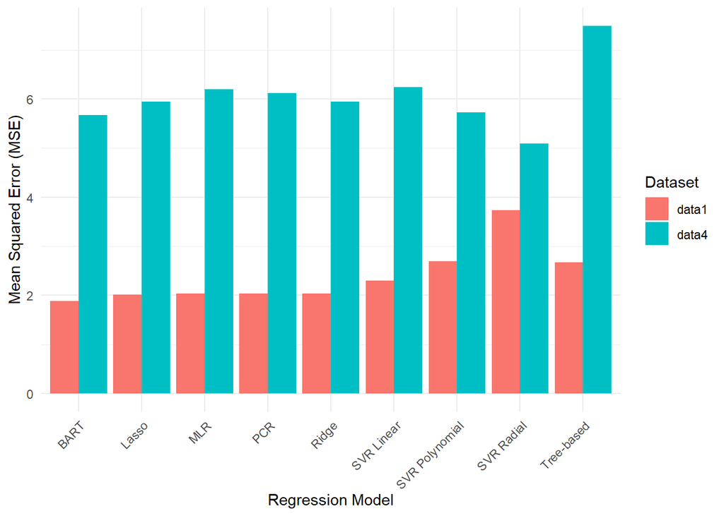

Comparison of MSE across regression models for data1 and data4.

```r
# Bar plot of MSE
mse_long <- mse_data %>%
  pivot_longer(cols = c(MSE_data1, MSE_data4), names_to = "Dataset", values_to = "MSE") %>%
  mutate(Dataset = if_else(Dataset == "MSE_data1", "data1", "data4"))

ggplot(mse_long, aes(x = Model, y = MSE, fill = Dataset)) +
  geom_bar(stat = "identity", position = "dodge") +
  theme_minimal() +
  labs(x = "Regression Model", y = "Mean Squared Error (MSE)") +
  theme(axis.text.x = element_text(angle = 45, hjust = 1))
```

```r
# Bar plot of MSE for data1, data2, data3, and data4
# mse_long <- mse_data %>%
#   pivot_longer(cols = c(MSE_data1, MSE_data2, MSE_data3, MSE_data4),
#                names_to = "Dataset",
#                values_to = "MSE") %>%
#   mutate(Dataset = case_when(
#     Dataset == "MSE_data1" ~ "data1",
#     Dataset == "MSE_data2" ~ "data2",
#     Dataset == "MSE_data3" ~ "data3",
#     Dataset == "MSE_data4" ~ "data4"
#   ))
#
# ggplot(mse_long, aes(x = Model, y = MSE, fill = Dataset)) +
#   geom_bar(stat = "identity", position = "dodge") +
#   theme_minimal() +
#   labs(x = "Regression Model", y = "Mean Squared Error (MSE)") +
#   theme(axis.text.x = element_text(angle = 45, hjust = 1))
```

Figure 1 visually compares MSE across models for `data1` and `data4`.

### Detailed Results for Best-Performing Models

#### BART on data1

BART achieved the lowest MSE on `data1`. The variable importance is calculated below:

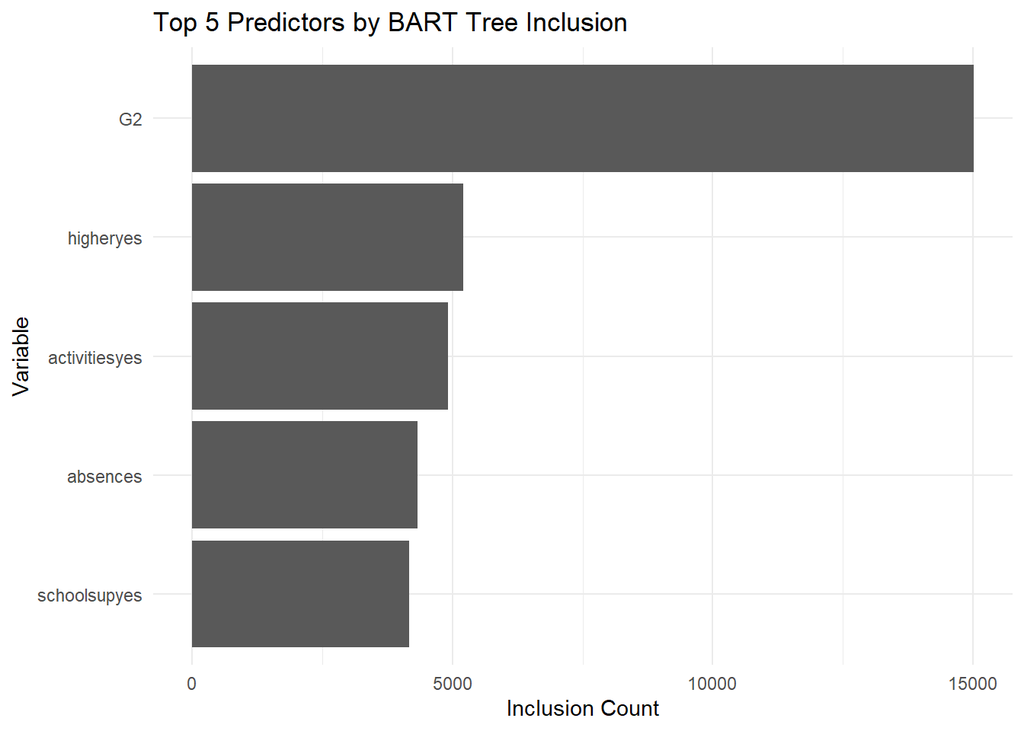

Variable Importance for BART on data1.

```r
var_counts <- colSums(fit_bart_1$varcount)

var_imp_df <- tibble(
  Variable   = names(var_counts),
  Importance = var_counts
) %>%
  arrange(desc(Importance)) %>%
  slice_head(n = 5)

ggplot(var_imp_df, aes(x = reorder(Variable, Importance), y = Importance)) +
  geom_bar(stat = "identity") +
  coord_flip() +
  labs(
    x     = "Variable",
    y     = "Inclusion Count",
    title = "Top 5 Predictors by BART Tree Inclusion"
  ) +
  theme_minimal()
```

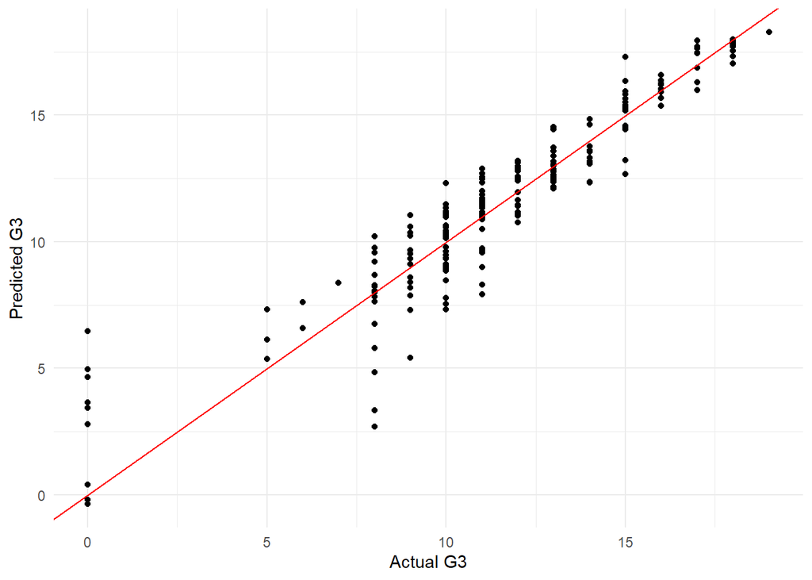

Predicted vs. Actual G3 for BART on data1.

```r
# Predicted vs. actual for BART
plot_data <- data.frame(Actual = test_reg_1$G3, Predicted = pred_bart_1)
ggplot(plot_data, aes(x = Actual, y = Predicted)) +
  geom_point() +
  geom_abline(slope = 1, intercept = 0, color = "red") +
  labs(x = "Actual G3", y = "Predicted G3") +
  theme_minimal()
```

Figure 3 shows a good fit between predicted and actual G3 values.

#### SVR Radial on data4

SVR Radial performed best on `data4`:

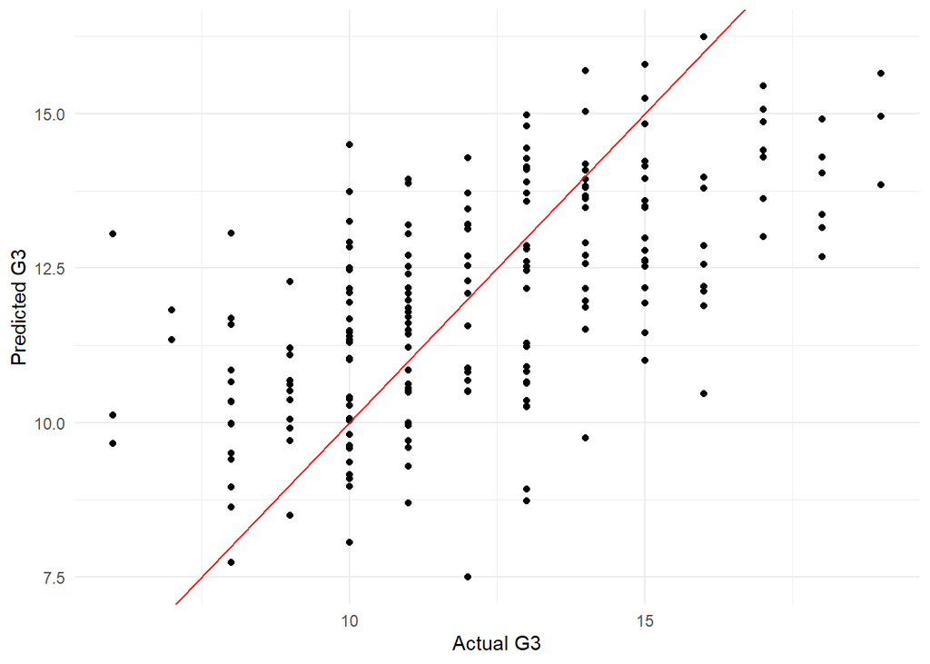

Predicted vs. Actual G3 for SVR Radial on data4.

```r
# Predicted vs. actual for SVR Radial
plot_data_4 <- data.frame(Actual = test_reg_4$G3, Predicted = pred_svr_radial_4)
ggplot(plot_data_4, aes(x = Actual, y = Predicted)) +
  geom_point() +
  geom_abline(slope = 1, intercept = 0, color = "red") +
  labs(x = "Actual G3", y = "Predicted G3") +
  theme_minimal()
```

### Impact of Feature Selection

```r
# Lasso coefficients for data1 and data4
lasso_coef_1 <- as.data.frame(as.matrix(coef(fit_lasso_1, s = bestlam_lasso_1)))
lasso_coef_4 <- as.data.frame(as.matrix(coef(fit_lasso_4, s = bestlam_lasso_4)))
lasso_coef_1$Feature <- rownames(lasso_coef_1)
lasso_coef_4$Feature <- rownames(lasso_coef_4)

# Rename coefficient columns
colnames(lasso_coef_1)[1] <- "Coefficient_data1"
colnames(lasso_coef_4)[1] <- "Coefficient_data4"

# Merge coefficients, keeping all features
lasso_table <- full_join(lasso_coef_1, lasso_coef_4, by = "Feature") %>%
  filter(Feature != "(Intercept)") %>%
  mutate(
    Coefficient_data1 = replace_na(Coefficient_data1, 0),
    Coefficient_data4 = replace_na(Coefficient_data4, 0)
  ) %>%
  filter(Coefficient_data1 != 0 | Coefficient_data4 != 0)

knitr::kable(lasso_table, format = "html", caption = "Features selected by Lasso regression for data1 and data4.", digits = 2) %>%
  kableExtra::kable_styling(bootstrap_options = c("striped", "hover"))
```

Features selected by Lasso regression for data1 and data4.

| Coefficient_data1 | Feature | Coefficient_data4 |
| --- | --- | --- |
| 0.07 | schoolMS | -0.50 |
| 0.00 | sexM | -0.02 |
| -0.03 | age | 0.12 |
| 0.00 | addressU | 0.07 |
| -0.02 | PstatusT | 0.00 |
| 0.00 | Medu | 0.19 |
| 0.00 | Fedu | 0.00 |
| 0.00 | Mjobhealth | 0.69 |
| 0.00 | Mjobservices | 0.44 |
| 0.00 | Fjobteacher | 1.06 |
| 0.00 | reasonhome | 0.28 |
| 0.00 | reasonreputation | 0.32 |
| 0.06 | guardianmother | 0.00 |
| 0.00 | guardianother | 0.19 |
| 0.05 | traveltime | 0.00 |
| 0.00 | studytime | 0.32 |
| -0.11 | failures | -1.19 |
| 0.00 | schoolsupyes | -1.48 |
| 0.06 | famsupyes | -0.11 |
| -0.24 | paidyes | -0.78 |
| -0.08 | activitiesyes | 0.12 |
| 0.00 | higheryes | 1.24 |
| 0.00 | internetyes | 0.21 |
| -0.02 | romanticyes | 0.00 |
| 0.06 | famrel | 0.05 |
| 0.00 | goout | -0.22 |
| 0.00 | Dalc | -0.15 |
| 0.00 | Walc | -0.04 |
| 0.00 | health | -0.09 |
| 0.02 | absences | -0.07 |
| 0.10 | G1 | 0.00 |
| 0.97 | G2 | 0.00 |

Table 2 shows features selected by Lasso, indicating modest improvements in MSE on `data1`.

### Effect of Dimensionality Reduction

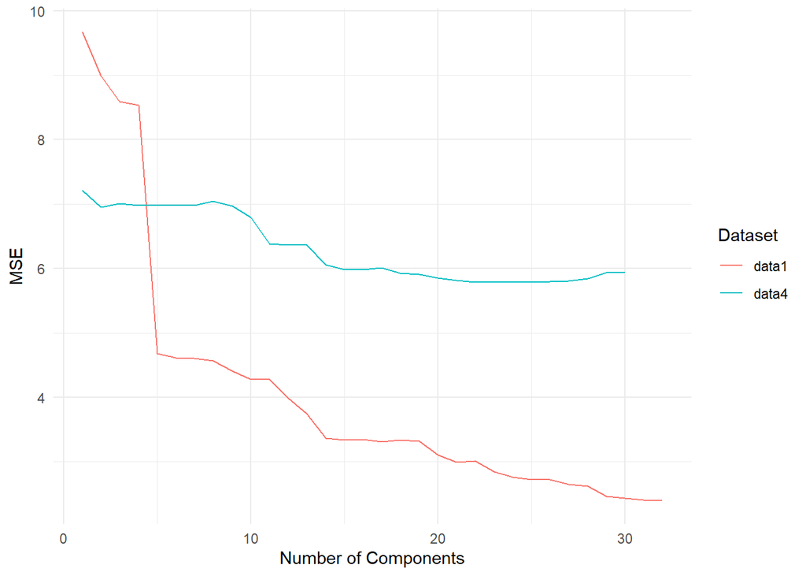

MSE vs. Number of Components for PCR on data1 and data4.

```r
# MSE vs. components for PCR
pcr_mse_1 <- sapply(1:ncol(predictors_1), function(n) mean((test_reg_1$G3 - predict(fit_pcr_1, test_reg_1, ncomp = n))^2))
pcr_mse_4 <- sapply(1:ncol(predictors_4), function(n) mean((test_reg_4$G3 - predict(fit_pcr_4, test_reg_4, ncomp = n))^2))
pcr_data <- data.frame(
  Components = c(1:ncol(predictors_1), 1:ncol(predictors_4)),
  MSE = c(pcr_mse_1, pcr_mse_4),
  Dataset = rep(c("data1", "data4"), times = c(ncol(predictors_1), ncol(predictors_4)))
)

ggplot(pcr_data, aes(x = Components, y = MSE, color = Dataset)) +
  geom_line() +
  labs(x = "Number of Components", y = "MSE") +
  theme_minimal()
```

Figure 5 shows that PCR’s MSE decreases with more components but does not outperform top models.

## Discussion

### Conclusive Remarks

- **Predictability of G3**: G3 is predictable, with BART excelling on `data1` and SVR Radial on `data4`. Higher MSE on `data4` suggests G1 and G2 are key predictors.
- **Feature Selection**: Lasso slightly improves accuracy on `data1`, but benefits are limited.
- **Dimensionality Reduction**: PCR underperforms, indicating loss of predictive information.

### Limitations

- **Data Quality**: Zeros in G3 may represent dropouts, skewing results.
- **Model Assumptions**: Linear models may miss non-linear relationships.
- **Sample Size**: The 80/20 split may limit generalizability.

### What We Would Do Differently

- Implement hyperparameter tuning for SVR and PCR.
- Use k-fold cross-validation for robust estimates.
- Explore feature engineering (e.g., interactions).